# Assignment 3

Catherine Saint

9/15/2020

### Topic Reminder

I want to explore the relationship between age, unemployment, educational attainment, race, and nativity on the census tract level in Los Angeles County.

## Relationships between age, unemployment, and educational attainment

First, I will test the relationship between my continuous variables - median age, percent unemployed, and percent highschool graduates - by running a correlation test.

```r
correlation1 <- cor.test(tract_data$med_ageE, tract_data$pct_unemp_labor)
correlation1
```

```
##
##  Pearson's product-moment correlation
##
## data:  tract_data$med_ageE and tract_data$pct_unemp_labor
## t = -15.632, df = 2322, p-value < 2.2e-16
## alternative hypothesis: true correlation is not equal to 0
## 95 percent confidence interval:
##  -0.3448959 -0.2713063
## sample estimates:
##        cor
## -0.3085627
```

```r
correlation2 <- cor.test(tract_data$med_ageE, tract_data$pct_hs_grad)
correlation2
```

```
##
##  Pearson's product-moment correlation
##
## data:  tract_data$med_ageE and tract_data$pct_hs_grad
## t = -19.053, df = 2322, p-value < 2.2e-16
## alternative hypothesis: true correlation is not equal to 0
## 95 percent confidence interval:
##  -0.4023430 -0.3320013
## sample estimates:
##        cor
## -0.3676979
```

```r
correlation3 <- cor.test(tract_data$pct_unemp_labor, tract_data$pct_hs_grad)
correlation3
```

```
##
##  Pearson's product-moment correlation
##
## data:  tract_data$pct_unemp_labor and tract_data$pct_hs_grad
## t = 3.4321, df = 2325, p-value = 0.0006093
## alternative hypothesis: true correlation is not equal to 0
## 95 percent confidence interval:
##  0.03045334 0.11131258
## sample estimates:
##       cor
## 0.0709996
```

The following statements can be made by looking at Pearson’s r and p-values for the correlation tests above.

- median age and unemployment: a weak, but statistically signficant, negative correlation at a 95% confidence level.
- median age and high school graduate: a weak, but statistically significant, negative correlation at a 95% confidence level.
- unemployment and highschool Ggraduate: a weak, but statistically significant, positive correlation at a 95% confidence level.

I want to see what these “weaker” relationships look like, so I chose median Age and unemployment to represent on a scatterplot.

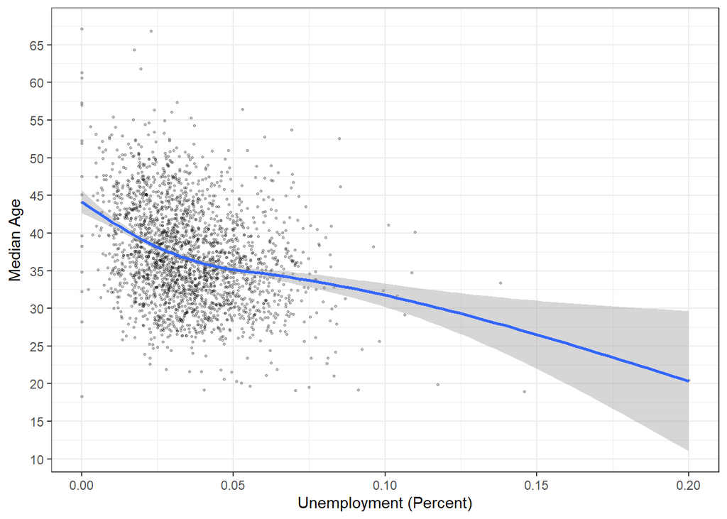

```r
ggplot(tract_data, aes(x = pct_unemp_labor, y = med_ageE)) +
    geom_point(size = 0.5, alpha = 0.25, position = "jitter") +
    geom_smooth() +
    theme_bw() +
    scale_x_continuous(name = "Unemployment (Percent)") +
    scale_y_continuous(name = "Median Age",
                      breaks = seq(0, 105, by = 5),
                      labels = paste("",
                                  prettyNum(seq(0, 105, by = 5),
                                            big.mark = ",")))
```

## Relationship between race and nativity

I use the chi-square test of association to determine whether there is a statistically signficant association between race and nativity.

```r
chi_sq <- chisq.test(tract_data$maj_race, tract_data$maj_foreign == "TRUE")
chi_sq
```

```
##
##  Pearson's Chi-squared test
##
## data:  tract_data$maj_race and tract_data$maj_foreign == "TRUE"
## X-squared = 342.95, df = 5, p-value < 2.2e-16
```

```r
chi_sq$observed
```

```
##
## tract_data$maj_race FALSE TRUE
##         hs_latino     948  136
##         native_am       2    0
##         nh_asian       48   76
##         nh_black       53    0
##         nh_white      520   24
##         no_majority   484   36
```

```r
chi_sq$expected
```

```
##
## tract_data$maj_race      FALSE        TRUE
##         hs_latino   957.292651 126.7073485
##         native_am     1.766223   0.2337774
##         nh_asian    109.505801  14.4941985
##         nh_black     46.804899   6.1951010
##         nh_white    480.412548  63.5874517
##         no_majority 459.217877  60.7821229
```

I see that the Native American category violates the chi-square observed table, as it has a value less than 5. However, with a p-value so much less than 0.05, we can assume a statistically significant relationship between race and nativity at a 95% confidence level despite this possible innacuracy.

## Relationships between race and continuous variables

I use the anova test to find the relationship between race and my continuous variables: age, unemployment, and educational attainment.

```r
anova <- aov (med_ageE ~ maj_race, data = tract_data)
summary(anova)
```

```
##               Df Sum Sq Mean Sq F value Pr(>F)
## maj_race       4  40724   10181   393.3 <2e-16 ***
## Residuals   2319  60035      26
## ---
## Signif. codes:  0 '***' 0.001 '**' 0.01 '*' 0.05 '.' 0.1 ' ' 1
## 22 observations deleted due to missingness
```

```r
anova <- aov (pct_hs_grad ~ maj_race, data = tract_data)
summary(anova)
```

```
##               Df Sum Sq Mean Sq F value Pr(>F)
## maj_race       5  1.525 0.30501     264 <2e-16 ***
## Residuals   2321  2.681 0.00116
## ---
## Signif. codes:  0 '***' 0.001 '**' 0.01 '*' 0.05 '.' 0.1 ' ' 1
## 19 observations deleted due to missingness
```

```r
anova <- aov (pct_unemp_labor ~ maj_race, data = tract_data)
summary(anova)
```

```
##               Df Sum Sq  Mean Sq F value Pr(>F)
## maj_race       5 0.0301 0.006025    21.4 <2e-16 ***
## Residuals   2321 0.6534 0.000282
## ---
## Signif. codes:  0 '***' 0.001 '**' 0.01 '*' 0.05 '.' 0.1 ' ' 1
## 19 observations deleted due to missingness
```

Difference Check:

```r
differences <- TukeyHSD(anova)
as_tibble(cbind(pair = row.names(differences$maj_race),
                differences$maj_race))
```

```
## # A tibble: 15 x 5
##    pair           diff           lwr           upr           `p adj`
##    <chr>          <chr>          <chr>         <chr>         <chr>
##  1 native_am-hs_~ -0.0378473659~ -0.071716712~ -0.003978019~ 0.01821812633~
##  2 nh_asian-hs_l~ -0.0088477678~ -0.013384357~ -0.004311177~ 4.42953263402~
##  3 nh_black-hs_l~ 0.01131191670~ 0.0045798377~ 0.0180439956~ 2.58427586283~
##  4 nh_white-hs_l~ -0.0056035326~ -0.008117934~ -0.003089130~ 3.73393271857~
##  5 no_majority-h~ -0.0035357142~ -0.006088459~ -0.000982969~ 0.00113050293~
##  6 nh_asian-nati~ 0.02899959809~ -0.005110343~ 0.0631095398~ 0.14805537370~
##  7 nh_black-nati~ 0.04915928265~ 0.0146885941~ 0.0836299711~ 0.00069804418~
##  8 nh_white-nati~ 0.03224383330~ -0.001656457~ 0.0661441237~ 0.07308914933~
##  9 no_majority-n~ 0.03431165166~ 0.0004084957~ 0.0682148076~ 0.04536297735~
## 10 nh_black-nh_a~ 0.02015968455~ 0.0123062541~ 0.0280131149~ 1.71784808600~
## 11 nh_white-nh_a~ 0.00324423520~ -0.001517875~ 0.0080063458~ 0.37605666881~
## 12 no_majority-n~ 0.00531205357~ 0.0005295867~ 0.0100945203~ 0.01937056134~
## 13 nh_white-nh_b~ -0.0169154493~ -0.023801517~ -0.010029381~ 6.00941518769~
## 14 no_majority-n~ -0.0148476309~ -0.021747792~ -0.007947469~ 1.47753611567~
## 15 no_majority-n~ 0.00206781836~ -0.000867067~ 0.0050027043~ 0.33707699140~
```

There exists a significant association between race and unemployment, race and median age, and race and education attainment level at a 95% confidence level. All p-values fall well below the 0.05 threshold.

I chose to display the relationship between median age and majority race using a box-plot.

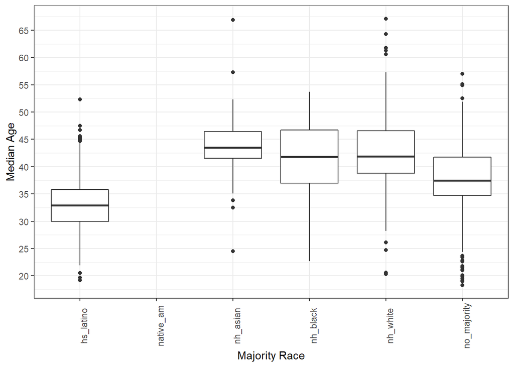

```r
ggplot(tract_data, aes(x = maj_race, y = med_ageE)) +
  geom_boxplot() +
  theme_bw() +
  theme(axis.text.x = element_text(angle = 90)) +
  scale_x_discrete(name = "Majority Race") +
  scale_y_continuous(name = "Median Age",
                     breaks = seq(0, 105, by = 5),
                     labels = paste(prettyNum(seq(0, 105, by = 5),
                                              big.mark = ",")))
```

## Relationships between nativity and continuous variables

I use a two-sample t-test to test the relationship between nativity and my continuous variables: age, unemployment, and educational attainment.

```r
difference1 = t.test(med_ageE ~ maj_foreign == "TRUE",
                    data = tract_data)
difference1
```

```
##
##  Welch Two Sample t-test
##
## data:  med_ageE by maj_foreign == "TRUE"
## t = -0.77298, df = 367.08, p-value = 0.44
## alternative hypothesis: true difference in means is not equal to 0
## 95 percent confidence interval:
##  -1.0684100  0.4654645
## sample estimates:
## mean in group FALSE  mean in group TRUE
##            37.03787            37.33934
```

```r
difference2 = t.test(pct_unemp_labor ~ maj_foreign == "TRUE",
                    data = tract_data)
difference2
```

```
##
##  Welch Two Sample t-test
##
## data:  pct_unemp_labor by maj_foreign == "TRUE"
## t = -2.1821, df = 352.35, p-value = 0.02976
## alternative hypothesis: true difference in means is not equal to 0
## 95 percent confidence interval:
##  -0.0044664148 -0.0002318602
## sample estimates:
## mean in group FALSE  mean in group TRUE
##          0.03522633          0.03757547
```

```r
difference3 = t.test(pct_hs_grad ~ maj_foreign == "TRUE",
                    data = tract_data)
difference3
```

```
##
##  Welch Two Sample t-test
##
## data:  pct_hs_grad by maj_foreign == "TRUE"
## t = -7.2528, df = 428.49, p-value = 1.925e-12
## alternative hypothesis: true difference in means is not equal to 0
## 95 percent confidence interval:
##  -0.01939292 -0.01112306
## sample estimates:
## mean in group FALSE  mean in group TRUE
##          0.08226583          0.09752382
```

There is no signficant relationship found between nativity and median age at a 95% confidence level.

There is a significant relationship found between unemployment and nativity at a 95% confidence level; tracts with a majority foreign born population have a higher unemployment percentage.

There is a strong, significant relationship found between educational attainment and nativity; tracts with a majority foreign born population have a larger percentage of highschool graduate (or equivalent) educational attainment than do majority native born tracts.